# Data 621 - Homework 2

## 11. Classification report

Use your created R functions and the provided classification output data set to produce all of the classification metrics discussed above.

```r
metrics <- c(accurary(data), cls_er_rate(data), precision(data), sensitivity(data), specificity(data), f1_score(data))
names(metrics) <- c("Accuracy", "Classification Error Rate", "Precision", "Sensitivity", "Specificity", "F1 Score")
as.data.frame(metrics, col.names = "Metrics")
```

|  | metrics |
| --- | --- |
| Accuracy | 0.8066000 |
| Classification Error Rate | 0.1934000 |
| Precision | 0.8438000 |
| Sensitivity | 0.4737000 |
| Specificity | 0.9597000 |
| F1 Score | 0.6067675 |

## 12. Caret investigation

Investigate the caret package. In particular, consider the functions confusionMatrix, sensitivity, and specificity. Apply the functions to the data set. How do the results compare with your own functions?

```r
# Investigating caret
b <- data %>%
  select(scored.class, class) %>%
  mutate(scored.class = as.factor(scored.class),
         class = as.factor(class))

c <- confusionMatrix(b$scored.class, b$class, positive = "1")

caret_package <- c(c$overall["Accuracy"], c$byClass["Sensitivity"], c$byClass["Specificity"])
written_function <- c(accurary(data), sensitivity(data), specificity(data))
d <- cbind(caret_package, written_function)
as.data.frame(d)
```

|  | caret_package | written_function |
| --- | --- | --- |
| Accuracy | 0.8066298 | 0.8066 |
| Sensitivity | 0.4736842 | 0.4737 |
| Specificity | 0.9596774 | 0.9597 |

The results from the caret package match our functions.

## 13. Investigate pROC

Investigate the pROC package. Use it to generate an ROC curve for the data set. How do the results compare with your own functions?

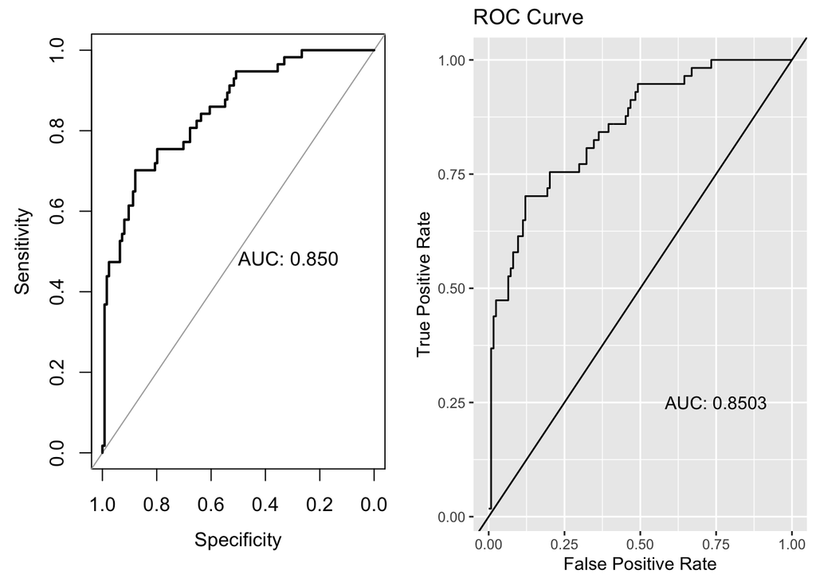

```r
# Investigating pROC
library(gridExtra)
library(ggplotify)
grid.arrange(as.grob(~plot(roc(data$class, data$scored.probability), print.auc = TRUE)), ROC(data$class,data$scored.probability)$plot, ncol=2)
```

As shown on the plots above, the results from the pROC package are in agreement with our own functions.